# DragRace12

Emily Nordmann

21/05/2020

```r
knitr::opts_chunk$set(warning = FALSE, message = FALSE)
# load packages
library(rtweet)
library(tidytext)
library(tidyverse)
library(extrafont)
library(readxl)
library(patchwork)
library(gridExtra)
library(waffle)
library(magick)
library(png)
library(grid)
```

## Retrieve tweets

`rtweet` can retrieve all tweets that use a particular hashtag or phrase. However, the search function is limited to retrieving a maximum of 18,000 from the last 7 days, it does not provide unlimited tweets from all time.

We retrieve all tweets that mention #TeamJaida, #TeamCrystal, and #TeamGigi. Note that any given tweet could contain one or more of these hashtags, so the tweet count is the number of times each hashtag was used in total, not the number of times it was used on its own.

```r
# get tweets with the team hashtags

TeamGigi <- search_tweets(
  "#TeamGigi", n = 18000, include_rts = FALSE)

TeamJaida <- search_tweets(
  "#TeamJaida", n = 18000, include_rts = FALSE)

TeamCrystal <- search_tweets(
  "#TeamCrystal", n = 18000, include_rts = FALSE)
```

```r
# get rid of numbers, links, and the hashtags then select timestamp and text columns

TeamGigi <- TeamGigi %>%
  mutate(text = str_replace_all(text, "[^\x01-\x7F]", ""),
         text = str_replace_all(text, "#DragRace", ""),
         text = str_replace_all(text, "#dragrace", ""),
         text = str_replace_all(text, "\\.|[[:digit:]]+", ""),
         text = str_replace_all(text, "https|amp|tco", ""))%>%
  select(created_at, text)%>%
  mutate(tweet = row_number())

TeamJaida <- TeamJaida %>%
  mutate(text = str_replace_all(text, "[^\x01-\x7F]", ""),
         text = str_replace_all(text, "#DragRace", ""),
         text = str_replace_all(text, "#dragrace", ""),
         text = str_replace_all(text, "\\.|[[:digit:]]+", ""),
         text = str_replace_all(text, "https|amp|tco", ""))%>%
  select(created_at, text)%>%
  mutate(tweet = row_number())

TeamCrystal <- TeamCrystal %>%
  mutate(text = str_replace_all(text, "[^\x01-\x7F]", ""),
         text = str_replace_all(text, "#DragRace", ""),
         text = str_replace_all(text, "#dragrace", ""),
         text = str_replace_all(text, "\\.|[[:digit:]]+", ""),
         text = str_replace_all(text, "https|amp|tco", ""))%>%
  select(created_at, text)%>%
  mutate(tweet = row_number())

dat <- bind_rows(TeamGigi, TeamJaida, TeamCrystal)

# write this to a file so that can reproduce in future

#write.csv(x = dat, file = "#Dragrace12 tweets 21-05-2020.csv")
```

```r
# reads in data to reproduce analysis after initial tweet stream
dat <- read_csv("#Dragrace12 tweets 21-05-2020.csv")

# create long-form tidy text to convert all to lower case
# convert tidy text back to wide so that all in lower case etc.
# add in column to say if each queen mentioned in tweet
# create long-form tidy text again, now with the mention columns


dat_token <- dat %>%
  unnest_tokens(word, text) %>%
  anti_join(stop_words, by = "word") %>%
  group_by(tweet) %>%
  summarise(text = str_c(word, collapse = " ")) %>%
  mutate(TeamGigi = case_when(str_detect(text, "teamgigi") ~ TRUE, TRUE ~ FALSE),
         TeamJaida = case_when(str_detect(text, "teamjaida") ~ TRUE, TRUE ~ FALSE),
         TeamCrystal = case_when(str_detect(text, "teamcrystal") ~ TRUE, TRUE ~ FALSE)) %>%
  unnest_tokens(word, text) %>%
  anti_join(stop_words, by = "word")
```

## Most popular hashtag

This plot shows the queen with the most frequently used hashtag in the last 7 days (can retrieve maximum of 18,000 unique tweets)

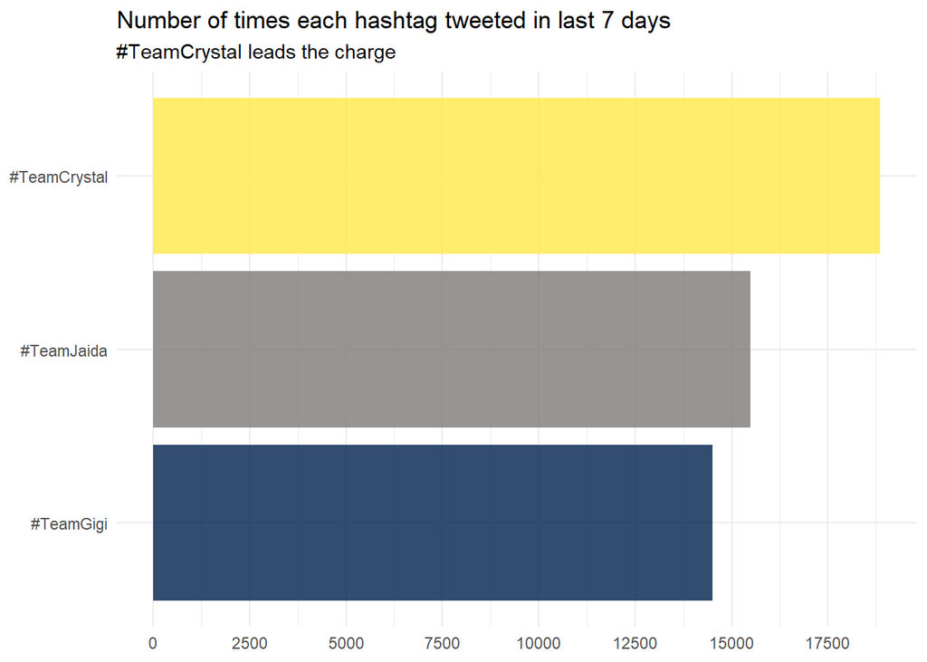

```r
# plot of the counts of most frequent names

dat_token %>%
  filter(word %in% c("teamgigi", "teamjaida", "teamcrystal"))%>%
  count(word, sort = TRUE) %>%
  head(20) %>%
  mutate(word = str_to_title(word),
         word = reorder(word, n))%>%
  ggplot(aes(x = word, y = n, fill = word)) +
  geom_col(show.legend = FALSE, alpha = .8) +
  coord_flip()+
  scale_y_continuous(breaks = c(0, 2500, 5000, 7500,
                                                           10000,12500,
                                                           15000,
                                                           17500))+
  scale_x_discrete(label = c("#TeamGigi", "#TeamJaida", "#TeamCrystal")) +
  labs(x = NULL, y = NULL, title = "Number of times each hashtag tweeted in last 7 days",
       subtitle = "#TeamCrystal leads the charge") +
  theme_minimal() +
  scale_fill_viridis_d(option = "E")
```

## Sentiment analyses

Sentiment analyses use information about the valance of words (i.e., whether they are positive or negative) to calculate an overall sentiment. This information is based upon ratings given by people in previous studies. Sentiment data is only available for words that were included in those previous studies, so there won’t be a rating for every single word in every tweet. Additionally, it can’t tell if there are non-standard uses of words - it will assume a sickening death drop is negative. So, caution is required.

The below graph shows the number of positive and negative words used in tweets that contained each hashtag. Remember that some tweets may have contained more than one hashtag so it’s a bit rough. The overall score is the number of positive words minus the number of negative words, so the higher this number, the bigger the ratio between negative and positive words for each hashtag.

```r
# do a sentiment analysis for each queen

sentiment_TeamGigi <- dat_token %>%
  filter(TeamGigi == "TRUE")%>%
  inner_join(get_sentiments("bing"))%>%
  count(index = tweet, sentiment) %>%
  spread(sentiment, n, fill = 0) %>%
  mutate(sentiment = positive - negative)%>%
  mutate(queen = "TeamGigi")

sentiment_TeamJaida <- dat_token %>%
  filter(TeamJaida == "TRUE")%>%
  inner_join(get_sentiments("bing"))%>%
  count(index = tweet, sentiment) %>%
  spread(sentiment, n, fill = 0) %>%
  mutate(sentiment = positive - negative)%>%
  mutate(queen = "TeamJaida")

sentiment_TeamCrystal <- dat_token %>%
  filter(TeamCrystal == "TRUE")%>%
  inner_join(get_sentiments("bing"))%>%
  count(index = tweet, sentiment) %>%
  spread(sentiment, n, fill = 0) %>%
  mutate(sentiment = positive - negative)%>%
  mutate(queen = "TeamCrystal")

# combine sentiment analysis for each queen into one tibble and then calculate total positive, negative
# and overall sentimment scores for each queen

dat_sentiment <- bind_rows(sentiment_TeamGigi,sentiment_TeamJaida,sentiment_TeamCrystal) %>%
  group_by(queen) %>%
  summarise(positive = sum(positive),
            negative = sum(negative),
            overall = sum(sentiment))%>%
  gather(positive:overall, key = type, value = score)%>%
  mutate(type = factor(type, levels = c("positive", "negative", "overall")))%>%
  mutate(queen = factor(queen, levels = c("TeamCrystal","TeamGigi", "TeamJaida")))
```

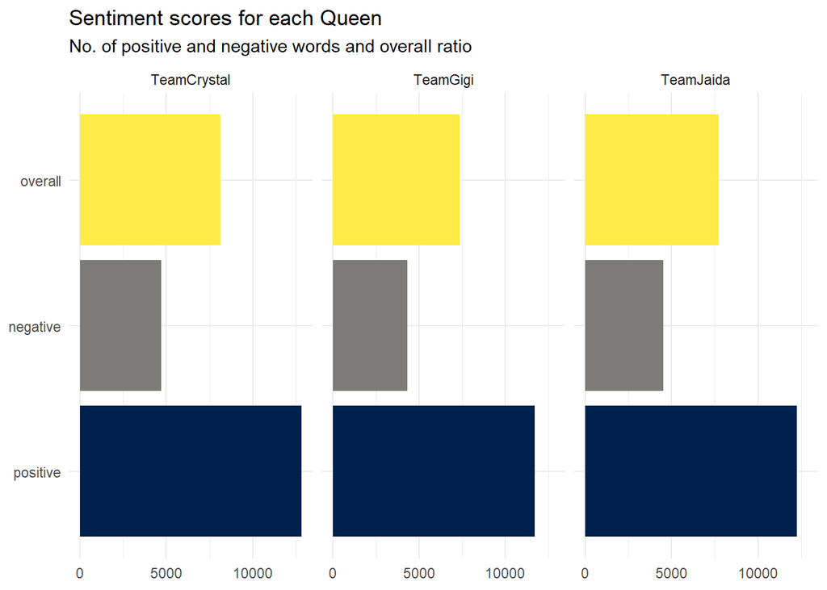

```r
# create plot of the sentiment scores by each queen, ordered by overall score

ggplot(dat_sentiment, aes(x = type, y = score, fill = type)) +
  stat_identity(geom = "bar", position = "dodge", show.legend = FALSE)+
  facet_wrap(~ queen, ncol = 3)+
  coord_flip()+
  scale_fill_viridis_d(option = "E") +
  labs(x = NULL, y = NULL, title = "Sentiment scores for each Queen",
       subtitle = "No. of positive and negative words and overall ratio") +
  theme_minimal()
```

Another simpler way to look at this is just the percent of words that are poisitve for each Queen, which is basically the same (look at the y-axis).

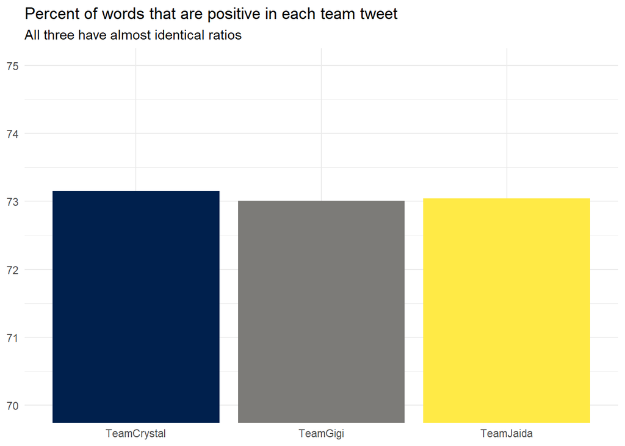

```r
dat_sentiment %>%
  spread(type, score) %>%
  mutate(percent_pos = positive / (positive+negative)*100) %>%
  ggplot(aes(x = queen, y = percent_pos, fill = queen)) +
  stat_identity(geom = "bar", position = "dodge", show.legend = FALSE)+
  scale_fill_viridis_d(option = "E") +
  labs(x = NULL, y = NULL,
       title = "Percent of words that are positive in each team tweet",
       subtitle = "All three have almost identical ratios") +
  scale_y_continuous(breaks = c(70,71,72,73,74,75)) +
  coord_cartesian(ylim=c(70,75)) +
  theme_minimal()
```